# Math 300 NTI Lesson 12

Simple Linear Regression - Discrete Predictor

Professor Bradley Warner

June, 2022

## Objectives

1. Explore the relationship between 2 variables, one numerical and one categorical, using summary statistics and visualizations in `R`.
2. Fit a linear regression model to two variables, one numerical response and one categorical predictor, using the `lm()` function and interpret the output. This includes the interpretation of baseline mean and offsets.
3. Generate a table of observations, fitted values, and residuals from a linear regression object.

## Reading

[Chapter 5.2](https://moderndive.com/5-regression.html#model2)

## Lesson

*Remember that you will be running this more like a lab than a lecture. You want them using `R` and answering questions. Have them open the notes rmd and work through it together.*

Work through the learning checks LC5.4 - LC5.7.

- The response `y` is the numeric variable. Math 378 discusses cases where the response is categorical. Understanding the regression output here is important. There is no line just a baseline average and offsets from that.
- The regression output will still predict the **mean** value of the response variable.
- The baseline is an **average** and is the first level of the factor based on alphabetic order.

### Setup

```r
library(tidyverse)
library(moderndive)
library(skimr)
library(gapminder)
```

*Create the data needed for the exercises.* As a reminder, in the text we explored the `gapminder` dataset only in the year 2007. We select only the variables `country`, `lifeExp`, `continent` and `gdpPercap`.

```r
gapminder2007 <- gapminder %>%
  filter(year == 2007) %>%
  select(country, lifeExp, continent, gdpPercap)
```

Let’s look at 5 random rows of data.

```r
set.seed(1234)
gapminder2007 %>%
  sample_n(size = 5)
```

```
## # A tibble: 5 x 4
##   country          lifeExp continent gdpPercap
##   <fct>              <dbl> <fct>         <dbl>
## 1 Congo, Dem. Rep.    46.5 Africa         278.
## 2 Mali                54.5 Africa        1043.
## 3 Peru                71.4 Americas      7409.
## 4 Senegal             63.1 Africa        1712.
## 5 Venezuela           73.7 Americas     11416.
```

### LC 5.4 (Objective 1)

**(LC5.4)** Conduct a new exploratory data analysis with the same explanatory variable $x$ being `continent` but with `gdpPercap` as the new outcome variable $y$. Remember, this involves three things:

- Most crucially: Looking at the raw data values.
- Computing summary statistics, such as means, medians, and interquartile ranges.
- Creating data visualizations.

What can you say about the differences in GDP per capita between continents based on this exploration?

**Solution**:

- Looking at the raw data values:

```r
glimpse(gapminder2007)
```

```
## Rows: 142
## Columns: 4
## $ country   <fct> "Afghanistan", "Albania", "Algeria", "Angola", "Argentina", ~
## $ lifeExp   <dbl> 43.828, 76.423, 72.301, 42.731, 75.320, 81.235, 79.829, 75.6~
## $ continent <fct> Asia, Europe, Africa, Africa, Americas, Oceania, Europe, Asi~
## $ gdpPercap <dbl> 974.5803, 5937.0295, 6223.3675, 4797.2313, 12779.3796, 34435~
```

- Computing summary statistics, such as means, medians, and interquartile ranges:

```r
gapminder2007 %>%
  select(gdpPercap, continent) %>%
  skim() %>%
  print()
```

```
## -- Data Summary ------------------------
##                            Values
## Name                       Piped data
## Number of rows             142
## Number of columns          2
## _______________________
## Column type frequency:
##   factor                   1
##   numeric                  1
## ________________________
## Group variables            None
##
## -- Variable type: factor -------------------------------------------------------
##   skim_variable n_missing complete_rate ordered n_unique
## 1 continent             0             1 FALSE          5
##   top_counts
## 1 Afr: 52, Asi: 33, Eur: 30, Ame: 25
##
## -- Variable type: numeric ------------------------------------------------------
##   skim_variable n_missing complete_rate   mean     sd   p0   p25   p50    p75
## 1 gdpPercap             0             1 11680. 12860. 278. 1625. 6124. 18009.
##     p100 hist
## 1 49357. ▇▂▁▂▁
```

```
## $factor
##
## -- Variable type: factor -------------------------------------------------------
##   skim_variable n_missing complete_rate ordered n_unique top_counts
## 1 continent             0             1 FALSE          5 Afr: 52, Asi: 33, Eur:~
##
## $numeric
##
## -- Variable type: numeric ------------------------------------------------------
##   skim_variable n_missing complete_rate   mean     sd   p0   p25   p50    p75
## 1 gdpPercap             0             1 11680. 12860. 278. 1625. 6124. 18009.
## # ... with 2 more variables: p100 <dbl>, hist <chr>
```

- Creating data visualizations:

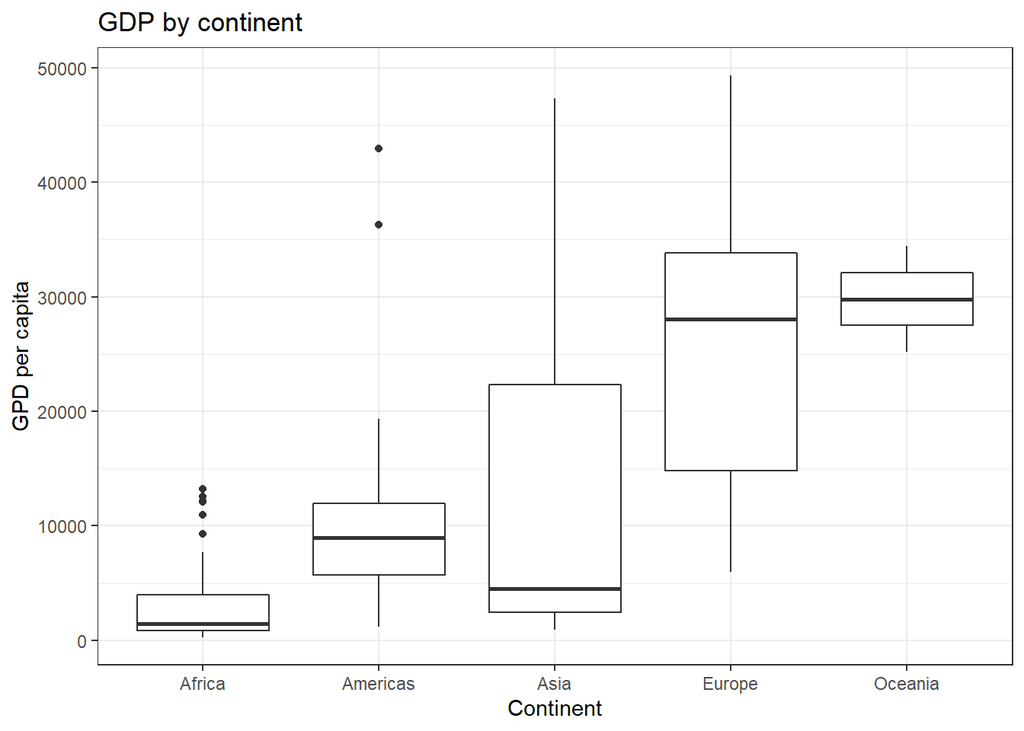

```r
ggplot(gapminder2007, aes(x = continent, y = gdpPercap)) +
  geom_boxplot() +
  labs(
    x = "Continent", y = "GPD per capita",
    title = "GDP by continent") +
  theme_bw()
```

Based on this exploration, it seems that GDP’s are very different among different continents, in terms of medians, variation, and symmetry. At a minimum this means that continent might be an important predictor for an area’s **mean** GDP.

### LC 5.5 (Objective 2)

**(LC5.5)** Fit a new linear regression using `lm(gdpPercap ~ continent, data = gapminder2007)` where `gdpPercap` is the new outcome variable $y$. Get information about the “best-fitting” line from the regression table by applying the `get_regression_table()` function. How do the regression results match up with the results from your previous exploratory data analysis?

**Solution**:

```r
# Fit regression model:
gdp_model <- lm(gdpPercap ~ continent, data = gapminder2007)
```

```r
# Get regression table:
get_regression_table(gdp_model)
```

```
## # A tibble: 5 x 7
##   term                estimate std_error statistic p_value lower_ci upper_ci
##   <chr>                  <dbl>     <dbl>     <dbl>   <dbl>    <dbl>    <dbl>
## 1 intercept              3089.     1373.      2.25   0.026     375.    5804.
## 2 continent: Americas    7914.     2409.      3.28   0.001    3150.   12678.
## 3 continent: Asia        9384.     2203.      4.26   0        5027.   13741.
## 4 continent: Europe     21965.     2270.      9.68   0       17478.   26453.
## 5 continent: Oceania    26721.     7133.      3.75   0       12616.   40826.
```

$$\begin{aligned}
\widehat{y} = \widehat{\text{gdpPercap}} &= b_0 + b_{\text{Amer}}\cdot\mathbb{1}_{\mbox{Amer}}(x) + b_{\text{Asia}}\cdot\mathbb{1}_{\mbox{Asia}}(x) + \\
& \qquad b_{\text{Euro}}\cdot\mathbb{1}_{\mbox{Euro}}(x) + b_{\text{Ocean}}\cdot\mathbb{1}_{\mbox{Ocean}}(x)\\
&= 3089 + 7914\cdot\mathbb{1}_{\mbox{Amer}}(x) + 9384\cdot\mathbb{1}_{\mbox{Asia}}(x) + \\
& \qquad 21965\cdot\mathbb{1}_{\mbox{Euro}}(x) + 26721\cdot\mathbb{1}_{\mbox{Ocean}}(x)
\end{aligned}$$

### LC 5.6 (Objective 3)

**(LC5.6)** Using either the sorting functionality of RStudio’s spreadsheet viewer or using the data wrangling tools you learned in Chapter 3, identify the five countries with the five smallest (most negative) residuals? What do these negative residuals say about their life expectancy relative to their continents?

**Solution**:

Use either the model with `gdpPercap` or the original model with life expectancy from the reading. Below, we switch to life expectancy. So, we need the model.

```r
lifeExp_model <- lm(lifeExp ~ continent, data = gapminder2007)
```

Let’s use `R`.

```r
get_regression_points(lifeExp_model, ID = "country") %>%
  arrange(residual) %>%
  slice_head(n=5)
```

```
## # A tibble: 5 x 5
##   country     lifeExp continent lifeExp_hat residual
##   <fct>         <dbl> <fct>           <dbl>    <dbl>
## 1 Afghanistan    43.8 Asia             70.7    -26.9
## 2 Swaziland      39.6 Africa           54.8    -15.2
## 3 Mozambique     42.1 Africa           54.8    -12.7
## 4 Haiti          60.9 Americas         73.6    -12.7
## 5 Zambia         42.4 Africa           54.8    -12.4
```

We can identify that the five countries with the five smallest (most negative) residuals are: Afghanistan, Swaziland, Mozambique, Haiti, and Zambia.

These negative residuals indicate that these data points have the biggest negative deviations from their group means. This means that these five countries’ average life expectancies are the lowest compared to their respective continents’ average life expectancies. For example, the residual for Afghanistan is $-26.9$ and it is the smallest residual. This means that the average life expectancy of Afghanistan is $26.9$ years lower than the average life expectancy of its continent, Asia.

### LC 5.7 (Objective 3)

**(LC5.7)** Repeat this process, but identify the five countries with the five largest (most positive) residuals. What do these positive residuals say about their life expectancy relative to their continents?

**Solution**:

Using `R`.

```r
get_regression_points(lifeExp_model, ID = "country") %>%
  arrange(desc(residual)) %>%
  slice_head(n=5)
```

```
## # A tibble: 5 x 5
##   country   lifeExp continent lifeExp_hat residual
##   <fct>       <dbl> <fct>           <dbl>    <dbl>
## 1 Reunion      76.4 Africa           54.8     21.6
## 2 Libya        74.0 Africa           54.8     19.1
## 3 Tunisia      73.9 Africa           54.8     19.1
## 4 Mauritius    72.8 Africa           54.8     18.0
## 5 Algeria      72.3 Africa           54.8     17.5
```

We can identify that the five countries with the five largest (most positive) residuals are: Reunion, Libya, Tunisia, Mauritius, and Algeria. (Note that Reunion is a French territory in the Indian Ocean.)

These positive residuals indicate that the data points are above the regression line with the longest distance. This means that these five countries’ average life expectancies are the highest comparing to their respective continents’ average life expectancies. For example, the residual for Reunion is $21.636$ and it is the largest residual. This means that the average life expectancy of Reunion is $21.636$ years higher than the average life expectancy of its continent, Africa.

## Documenting software

- File creation date: 2022-06-23
- R version 4.1.1 (2021-08-10)
- `tidyverse` package version: 1.3.1
- `skimr` package version: 2.1.4
- `gapminder` package version: 0.3.0
- `moderndive` package version: 0.5.4